# Personal Activity Monitors

Cary Correia

December 16, 2014

### Executive Summary

Using devices such as Jawbone Up, Nike FuelBand, and Fitbit it is now possible to collect a large amount of data about personal activity relatively inexpensively. These type of devices are part of the quantified self movement – a group of enthusiasts who take measurements about themselves regularly to improve their health, to find patterns in their behavior, or because they are tech geeks.

The goal of this project is to use data from accelerometers on the belt, forearm, arm, and dumbell of 6 participants and to build a model that can predict the manner in which they performed barbell lifts correctly (A-E). More information is available from the website here: http://groupware.les.inf.puc-rio.br/har.

The analytical flow was as follows: 1) download datasets; Training and Validation, (2) Clean and prep both datasets, (3) Figure out what data is not important with a screen model (4) Create a tuned model with a reduced variable set (5) Test the new model on the ‘testing’ dataset and (6) Use the final model to predict the values in the sample test data (20 rows)

Final results showed a final model accuracy of 99.04% with an out of sample error equal to 0.96%. These results were verified with cross-validation via a training (60% of sample) and testing (40%) set of data. Final prediction on our sample of 20 test scenarios yielded 100% (see report)

#### Section 1) download datasets; Training and Testing

```r
#Prep....setup libraries and set.seed
library(caret);library(randomForest); set.seed(12142014)
```

```r
#Set the train and test url's
data.url<-'http://d396qusza40orc.cloudfront.net/predmachlearn/pml-training.csv'
test.url<-'http://d396qusza40orc.cloudfront.net/predmachlearn/pml-testing.csv'

#Get and save the data
data       <-read.csv(url(data.url), header=TRUE, sep=",", fill=TRUE, na.strings=c("NA", "", " "))
validation <- read.csv(url(test.url), header=TRUE, sep=",", na.strings="NA")
```

#### Section 2) Clean and prep both datasets

```r
# Create a function to detect which column has lots of NA's - count #NA's / totalRows
na.test <- function(x,y) {
    w<-sapply(x, function(x)length(which(!is.na(x)))/length(x)*100)          # calculate %-age of rows that are NA in each col
    z<<-as.data.frame(sapply(w, function(x)if(x>=y) keep<-x else keep<-NA))  # creates a vector keep that has columns we will keep
    names(z)<<-c("value")                                                    # fixes the header of the z table
}
na.test(data, 99)                                                       # input-> dataset + threshold for non-NA's
keep<-as.data.frame(row.names(na.omit(z))); names(keep)<-'label'
keep<-as.character(keep$label[8:60])                                    # output-> vector of all rows to keep

data<-data[,names(data) %in% keep]                                      # downselect the variables we want
nzero<-nearZeroVar(data, saveMetrics=TRUE)                              # check all remaining vars to see if they are near zero
                                                                        # no non zero's were found- so nothing else to remove
inTrain    <-createDataPartition(data$classe, p=.20, list = FALSE)      # create inTrain string for data partitions
training   <-data[inTrain,]                                             # this sample for 1st round eval of variables is low=3.9K
```

#### Section 3) Figure out what data is not important

```r
library(doMC)                                                                   # this code enables parllel processing
registerDoMC(cores = 4)                                                         # All subsequent models are then run in parallel

screen<-randomForest(classe ~., data=training, importance=TRUE, proximity=TRUE) # 1st screen--> 3.9K obs with 53 variables....
vi<-importance(screen)                                                          # Create varImportance matrix
vi_vals<-as.data.frame(vi[,1:5])                                                # Save raw scores-> Higher is better
top_vi<-as.data.frame(apply(vi_vals, 2, rank))                                  # Convert scores to rank
top_vi$total<-rowSums(top_vi); top_sort<-top_vi[order(-top_vi$total),]          # Sum ranks-> Hi totals = more importance
```

The following chart illustrates the variables from most important to least. We will now introduce a cutoff to shrink the number of variables in the next model. Note: the variable importance chart values were replaced with force rank scores. By adding across the scores it was easy to assess which variables were the most valuable in our model:

```
##                       A  B  C  D  E total
## roll_belt            50 51 51 52 52   256
## magnet_dumbbell_z    52 49 52 50 51   254
## yaw_belt             51 50 48 51 46   246
## magnet_dumbbell_y    49 48 50 48 48   243
## pitch_belt           48 52 46 47 49   242
## pitch_forearm        47 46 49 49 50   241
## roll_dumbbell        45 47 45 44 45   226
## accel_dumbbell_y     43 44 44 40 44   215
## magnet_belt_y        39 45 42 45 40   211
## roll_forearm         46 36 47 37 41   207
## magnet_dumbbell_x    44 38 43 42 33   200
## accel_dumbbell_z     41 41 28 41 47   198
## magnet_belt_z        40 33 34 46 42   195
## gyros_belt_z         35 43 40 32 43   193
## accel_forearm_x      33 35 39 43 38   188
## magnet_forearm_z     42 32 35 36 35   180
## roll_arm             34 42 30 38 28   172
## yaw_dumbbell         27 39 32 35 39   172
## yaw_arm              38 28 38 39 26   169
## accel_belt_z         32 34 31 33 30   160
## gyros_dumbbell_y     36 30 41 27 25   159
## accel_dumbbell_x     30 37 29 26 36   158
## magnet_forearm_y     31 27 37 28 31   154
## magnet_belt_x        26 40 36 19 29   150
## total_accel_dumbbell 29 29 24 31 37   150
## accel_forearm_z      28 18 27 30 34   137
## yaw_forearm          23 15 26 25 32   121
## magnet_arm_z         37 25 21 16 13   112
## gyros_arm_y          19 31 14 29 18   111
## gyros_dumbbell_x     16 23 33 18 20   110
## accel_arm_x          21 16 16 34 22   109
## pitch_arm            15 22 19 22 24   102
## magnet_forearm_x     22 12 17 23 27   101
## magnet_arm_x         24 10 25 21 19    99
## accel_belt_x         14 20 23 10 10    77
## pitch_dumbbell        8 19 20 12 17    76
## magnet_arm_y         10 14 18 24  9    75
## accel_arm_y          18 13  9 17 15    72
## accel_forearm_y      20  7 22 11 12    72
## gyros_arm_x          13 26  4 15  8    66
## total_accel_arm       2  8 11 20 21    62
## accel_arm_z          11  4 15 14 16    60
## total_accel_belt      9  9 10  6 23    57
## total_accel_forearm  25  5 13  3 11    57
## gyros_dumbbell_z     12 17  2  4 14    49
## gyros_belt_x         17  3 12  7  6    45
## gyros_forearm_y       4 21  8  8  4    45
## gyros_forearm_z       7 24  3  5  2    41
## gyros_belt_y          3 11  6 13  7    40
## accel_belt_y          5  6  7  2  5    25
## gyros_forearm_x       6  2  5  9  3    25
## gyros_arm_z           1  1  1  1  1     5
```

#### Section (4) Create a tuned model with a reduced variable set-> but only use the variables that pass section (3)

```r
# cut off the bottom of the variables....include these for the actual full model run
keep2<-as.character(row.names(top_sort[top_sort$total>=88,]))                   # Take only variables >=88
keep2[37]<-"classe"                                                             # Add back in the "classe" output

data2<-data[,names(data) %in% keep2]                                            # Build the dataset with just the top values
inTrain2    <-createDataPartition(data2$classe, p=.60, list = FALSE)            # create inTrain string for data partitions   (60:40 split)
training2   <-data2[inTrain2,]                                                  # split data into training and testing
testing2    <-data2[-inTrain2,]

model<-train(classe ~., data=training2, method='rf', importance=TRUE)           # final model: random forest--> 12K obs with 36 variables
vi2<-varImp(model)
```

#### Section 5) Test the new model on the ‘testing’ dataset

```r
accuracy<-confusionMatrix(testing2$classe, predict(model, testing2))            # apply model to testing data
accuracy                                                                        # print out accuracy (99.06%)
```

```
## Confusion Matrix and Statistics
##
##           Reference
## Prediction    A    B    C    D    E
##          A 2228    4    0    0    0
##          B   11 1501    6    0    0
##          C    0   18 1348    2    0
##          D    0    0   23 1261    2
##          E    0    0    2    7 1433
##
## Overall Statistics
##
##                Accuracy : 0.9904
##                  95% CI : (0.988, 0.9925)
##     No Information Rate : 0.2854
##     P-Value [Acc > NIR] : < 2.2e-16
##
##                   Kappa : 0.9879
##  Mcnemar's Test P-Value : NA
##
## Statistics by Class:
##
##                      Class: A Class: B Class: C Class: D Class: E
## Sensitivity            0.9951   0.9856   0.9775   0.9929   0.9986
## Specificity            0.9993   0.9973   0.9969   0.9962   0.9986
## Pos Pred Value         0.9982   0.9888   0.9854   0.9806   0.9938
## Neg Pred Value         0.9980   0.9965   0.9952   0.9986   0.9997
## Prevalence             0.2854   0.1941   0.1758   0.1619   0.1829
## Detection Rate         0.2840   0.1913   0.1718   0.1607   0.1826
## Detection Prevalence   0.2845   0.1935   0.1744   0.1639   0.1838
## Balanced Accuracy      0.9972   0.9914   0.9872   0.9946   0.9986
```

The accuracy of the model is 99.04 and the out of sample error is 0.96

##### Section 6) Use the finalModel to predict the values in the sample test data (20 rows)

```r
# prep validation data
keep2[37]<- "problem_id"                                                        # fix keep2 vector and replace classe with prob ID
test_final<-validation[,names(validation) %in% keep2]                           # prep the test data to downselect the model variables
f.predict<-as.character(predict(model, test_final))                             # create a final prediction vector w. 20 answers
```

The final predicted string for the 20 test samples was B, A, B, A, A, E, D, B, A, A, B, C, B, A, E, E, A, B, B, B.  
This list was submitted and all 20 were correct.

#### Appendix

Full Variable Importance Matrix for all outcomes 1-5:

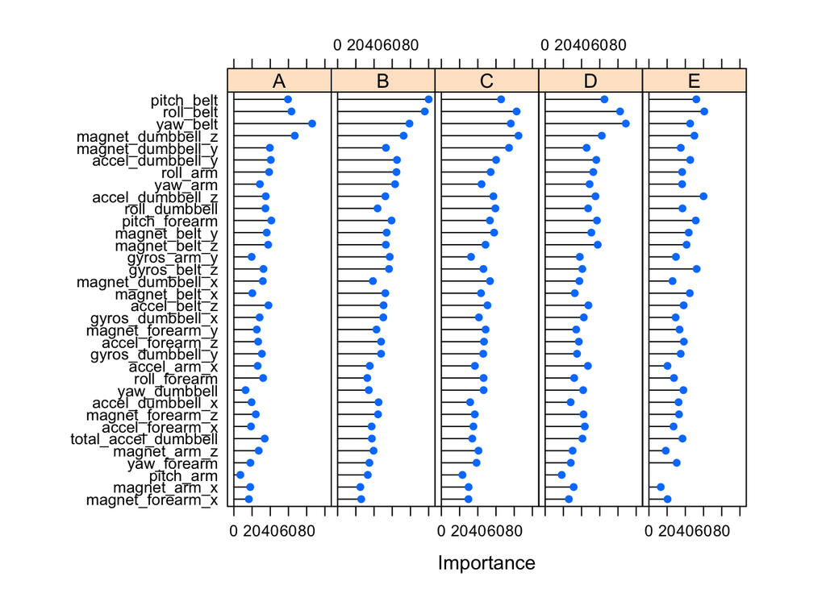

```r
plot(vi2, asp=4)
```